# ELMER: An R/Bioconductor Tool Inferring Regulatory Element Landscapes and Transcription Factor Networks Using Methylomes

Lijing Yao, Tiago Chedraoui Silva [ctb], Simon Coetzee [ctb], Ben Berman [aut], Peggy Farnham [aut], Hui Shen [ctb], Peter Laird [ctb]

2017-07-17

# Analysis

## Identifying regulatory TFs

This step is to identify regulatory TF whose expression associates with TF binding motif DNA methylation which is carried out by function `get.TFs`.

For each motif considered to be enriched within a particular probe set, it will compare the average DNA methylation at all distal enhancer probes within ±250*b**p*  
of a motif occurrence, to the expression of human TFs. A statistical test was performed for each motif-TF pair, as follows. The samples (all groups samples) were divided into two groups: the M group, which consisted of the 20% of samples with the highest average methylation at all motif-adjacent probes, and the U group, which consisted of the 20% of samples with the lowest methylation. For each candidate motif-TF pair, the Mann-Whitney U test was used to test the null hypothesis that overall gene expression in group M was greater or equal than that in group U. All TFs were ranked by the −*l**o**g*<sub>10</sub>(*P*<sub>*r*</sub>), and those falling within the top 5% of this ranking were considered candidate upstream regulators.

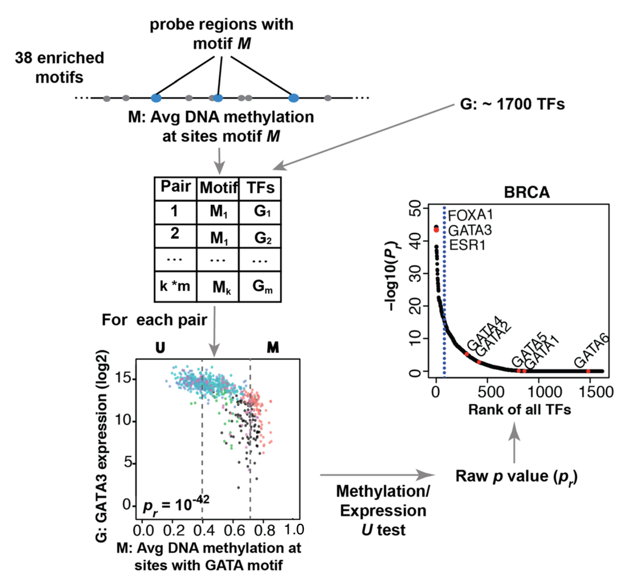

(Yao et al. 2015,Yao, Berman, and Farnham (2015))

[output not shown]

```r
# Load results from previous sections
mae <- get(load("mae.rda"))
load("result/getMotif.hypo.enriched.motifs.rda")

## identify regulatory TF for the enriched motifs
TF <- get.TFs(data = mae,
              group.col = "definition",
              group1 =  "Primary solid Tumor",
              group2 = "Solid Tissue Normal",
              minSubgroupFrac = 0.4,
              enriched.motif = enriched.motif,
              dir.out = "result",
              cores = 1,
              label = "hypo")
```

```r
# get.TFs automatically save output files.
# getTF.hypo.TFs.with.motif.pvalue.rda contains statistics for all TF with average
# DNA methylation at sites with the enriched motif.
# getTF.hypo.significant.TFs.with.motif.summary.csv contains only the significant probes.
dir(path = "result", pattern = "getTF")
```

```
## [1] "getTF.hypo.significant.TFs.with.motif.summary.csv"
## [2] "getTF.hypo.TFs.with.motif.pvalue.rda"
```

```r
# TF ranking plot based on statistics will be automatically generated.
dir(path = "result/TFrankPlot_family/", pattern = "pdf")
```

```
##  [1] "ARI3A_HUMAN.H10MO.D.TFrankPlot.pdf"
##  [2] "ARI5B_HUMAN.H10MO.C.TFrankPlot.pdf"
##  [3] "BARH1_HUMAN.H10MO.D.TFrankPlot.pdf"
##  [4] "BARX1_HUMAN.H10MO.D.TFrankPlot.pdf"
##  [5] "BATF_HUMAN.H10MO.S.TFrankPlot.pdf"
##  [6] "BCL6_HUMAN.H10MO.C.TFrankPlot.pdf"
##  [7] "CDC5L_HUMAN.H10MO.D.TFrankPlot.pdf"
##  [8] "CDX1_HUMAN.H10MO.C.TFrankPlot.pdf"
##  [9] "CDX2_HUMAN.H10MO.C.TFrankPlot.pdf"
## [10] "CEBPD_HUMAN.H10MO.B.TFrankPlot.pdf"
## [11] "CEBPG_HUMAN.H10MO.C.TFrankPlot.pdf"
## [12] "CPEB1_HUMAN.H10MO.D.TFrankPlot.pdf"
## [13] "DMBX1_HUMAN.H10MO.D.TFrankPlot.pdf"
## [14] "E2F8_HUMAN.H10MO.D.TFrankPlot.pdf"
## [15] "EVX1_HUMAN.H10MO.D.TFrankPlot.pdf"
```

[output cut: 62 more lines]

# Bibliography

Yao, Lijing, Benjamin P Berman, and Peggy J Farnham. 2015. “Demystifying the Secret Mission of Enhancers: Linking Distal Regulatory Elements to Target Genes.” *Critical Reviews in Biochemistry and Molecular Biology* 50 (6). Taylor & Francis: 550–73.

Yao, Lijing, Hui Shen, Peter W Laird, Peggy J Farnham, and Benjamin P Berman. 2015. “Inferring Regulatory Element Landscapes and Transcription Factor Networks from Cancer Methylomes.” *Genome Biology* 16 (1). BioMed Central: 105.